# STAT545 HW01

Ernest Lai

September 17, 2018

# R Markdown

This is the R Markdown document for hw01, which explores the **gapminder** dataset. To explore the data, we first have to install the ‘gapminder’ package through **install.packages(‘gapminder’)** and open the dataset into our R-Studio environment through **library(gapminder)**.

*For additional information on functions used in this exercise, type “?” and the function as one word in the console and the R help documentation will explain the function and the object needed to run the function successfully*

## Viewing and Exploring the dataset

To first explore contents of the dataset, we should assign our gapminder dataset to a variable called ‘data’. Prior to this, please be reminded to do a one-time installation of gapminder dataset via **install.packages(‘gapminder’)**:

```r
library(gapminder)
data <- gapminder
```

*The statements message=FALSE and warning=FALSE excludes external warning messages or output messages from being printed in the HTML version*

From this point on, any work associated with gapminder in this R-Studio session will be referenced to the variable called ‘data’. Lets try exploring the gapminder dataset:

```r
 # Provides number of observations and variables, also the class of each variable in the gapminder dataset
str(data)
```

```
## Classes 'tbl_df', 'tbl' and 'data.frame':    1704 obs. of  6 variables:
##  $ country  : Factor w/ 142 levels "Afghanistan",..: 1 1 1 1 1 1 1 1 1 1 ...
##  $ continent: Factor w/ 5 levels "Africa","Americas",..: 3 3 3 3 3 3 3 3 3 3 ...
##  $ year     : int  1952 1957 1962 1967 1972 1977 1982 1987 1992 1997 ...
##  $ lifeExp  : num  28.8 30.3 32 34 36.1 ...
##  $ pop      : int  8425333 9240934 10267083 11537966 13079460 14880372 12881816 13867957 16317921 22227415 ...
##  $ gdpPercap: num  779 821 853 836 740 ...
```

```r
# Information provided for each variable for the first 6 observed entries in the gapminder dataset
head(data)
```

```
## # A tibble: 6 x 6
##   country     continent  year lifeExp      pop gdpPercap
##   <fct>       <fct>     <int>   <dbl>    <int>     <dbl>
## 1 Afghanistan Asia       1952    28.8  8425333      779.
## 2 Afghanistan Asia       1957    30.3  9240934      821.
## 3 Afghanistan Asia       1962    32.0 10267083      853.
## 4 Afghanistan Asia       1967    34.0 11537966      836.
## 5 Afghanistan Asia       1972    36.1 13079460      740.
## 6 Afghanistan Asia       1977    38.4 14880372      786.
```

```r
# Number of rows in gapminder dataset (or number of observations)
nrow(data)
```

```
## [1] 1704
```

```r
# Number of columns in gapminder dataset (or number of variables)
ncol(data)
```

```
## [1] 6
```

## Summary Statistics

We can produce summary statistics for specific variables within the gapminder dataset, by adding the syntax ‘$’ after the gapminder dataset name (data), followed by the variable name in the gapminder dataset

```r
# Gives the frequency of each country in the dataset
table(data$country)
```

```
##
##              Afghanistan                  Albania                  Algeria
##                       12                       12                       12
##                   Angola                Argentina                Australia
##                       12                       12                       12
##                  Austria                  Bahrain               Bangladesh
##                       12                       12                       12
##                  Belgium                    Benin                  Bolivia
##                       12                       12                       12
##   Bosnia and Herzegovina                 Botswana                   Brazil
##                       12                       12                       12
##                 Bulgaria             Burkina Faso                  Burundi
##                       12                       12                       12
##                 Cambodia                 Cameroon                   Canada
##                       12                       12                       12
## Central African Republic                     Chad                    Chile
##                       12                       12                       12
##                    China                 Colombia                  Comoros
##                       12                       12                       12
##         Congo, Dem. Rep.              Congo, Rep.               Costa Rica
##                       12                       12                       12
##            Cote d'Ivoire                  Croatia                     Cuba
##                       12                       12                       12
##           Czech Republic                  Denmark                 Djibouti
##                       12                       12                       12
##       Dominican Republic                  Ecuador                    Egypt
##                       12                       12                       12
##              El Salvador        Equatorial Guinea                  Eritrea
##                       12                       12                       12
##                 Ethiopia                  Finland                   France
##                       12                       12                       12
##                    Gabon                   Gambia                  Germany
##                       12                       12                       12
##                    Ghana                   Greece                Guatemala
##                       12                       12                       12
##                   Guinea            Guinea-Bissau                    Haiti
##                       12                       12                       12
##                 Honduras         Hong Kong, China                  Hungary
##                       12                       12                       12
##                  Iceland                    India                Indonesia
```

[output cut: 42 more lines]

```
##                       12                       12                       12
##              Switzerland                    Syria                   Taiwan
##                       12                       12                       12
##                 Tanzania                 Thailand                     Togo
##                       12                       12                       12
##      Trinidad and Tobago                  Tunisia                   Turkey
##                       12                       12                       12
##                   Uganda           United Kingdom            United States
##                       12                       12                       12
##                  Uruguay                Venezuela                  Vietnam
##                       12                       12                       12
##       West Bank and Gaza              Yemen, Rep.                   Zambia
##                       12                       12                       12
##                 Zimbabwe
##                       12
```

```r
# Gives the frequency of each continent in the dataset
table(data$continent)
```

```
##
##   Africa Americas     Asia   Europe  Oceania
##      624      300      396      360       24
```

```r
# Number of countries in the data set
length(
  table(data$country)
  )
```

```
## [1] 142
```

```r
# Number of continents in the data set
length(
  table(data$continent)
  )
```

```
## [1] 5
```

```r
# Gives the average population based on all the countries in the data set
mean(data$pop)
```

```
## [1] 29601212
```

```r
# Gives the variance of the population based on all countries in the data set
var(data$pop)
```

```
## [1] 1.12695e+16
```

```r
# Gives the 1st quartile, median, third quartile, minimum, maximum, and average values for GDP per capita
summary(data$gdpPercap)
```

```
##     Min.  1st Qu.   Median     Mean  3rd Qu.     Max.
##    241.2   1202.1   3531.8   7215.3   9325.5 113523.1
```

## Summary Statistics with Specific Requirements

As seen in the dataset, there are a lot different countries being observed. What if we are interested in the average or range of the population for a specific country? Or GDP per capita given a certain continent? Or even average population with a given range of GDP per capita?

```r
# Takes the average population for Montenegro (average population, given country = Montenegro)
mean(
  data$pop[data$country == "Montenegro"]
  )
```

```
## [1] 564269.7
```

```r
# Max, min, mean, median, Q1, and A3 values for population in the Asia continent
summary(
  data$pop[data$continent == "Asia"]
  )
```

```
##      Min.   1st Qu.    Median      Mean   3rd Qu.      Max.
## 1.204e+05 3.844e+06 1.453e+07 7.704e+07 4.630e+07 1.319e+09
```

```r
# Max, min, mean, median, Q1, and A3 values for GDP per capita in the Europe continent
summary(
  data$gdpPercap[data$continent == "Europe"]
  )
```

```
##    Min. 1st Qu.  Median    Mean 3rd Qu.    Max.
##   973.5  7213.1 12081.8 14469.5 20461.4 49357.2
```

```r
# Mean population of countries with GDP per capita between 1202.1 and 3531.8 inclusive.
mean(
  data$pop[data$gdpPercap >= '1202.1' & data$gdpPercap <= '3531.8']
  )
```

```
## [1] 30745781
```

## Including Plots

Plots can also be made for each variable. Which plot we use is dependent on the type of data we are dealing with (ie. continuous, discrete, etc)

[figure not shown]

```r
# Boxplot of population for Morocco
boxplot(
  data$pop[data$country == 'Morocco'],
  ylab = 'Population', xlab ='Country', main = 'Frequency of Each Continent in gapminder Dataset'
  )
```

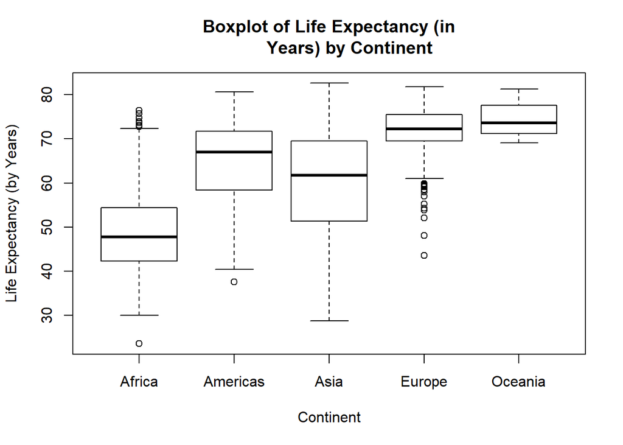

```r
# Boxplot of life expectancy for each continent
boxplot(data$lifeExp ~ data$continent,
        xlab = 'Continent', ylab = 'Life Expectancy (by Years)', main = 'Boxplot of Life Expectancy (in
        Years) by Continent'
        )
```

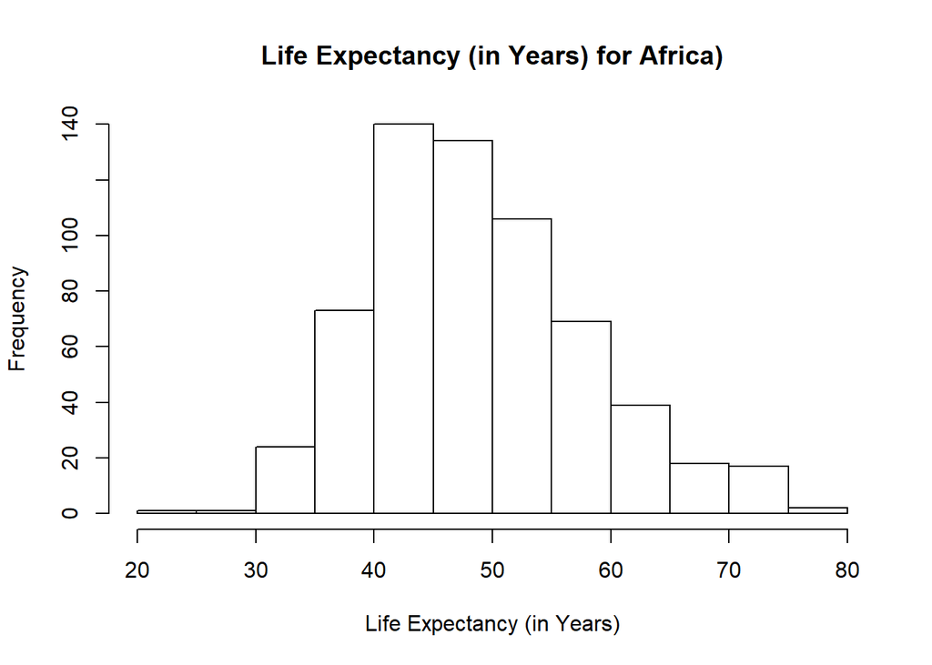

```r
# Histogram of Life Expectancy for the African Continent
hist(data$lifeExp[data$continent =='Africa'],
     xlab='Life Expectancy (in Years)', ylab='Frequency', main = 'Life Expectancy (in Years) for Africa)'
     )
```